# Module 8: Time Series Analysis in Google Earth Engine

Developed by the Graduate Degree Program in Ecology and the Natural Resource Ecology Laboratory at CSU Authors: Dan Carver, Peder Engelstad

Updated September, 2019

# 1 Introduction

In this module, we will discuss the following concepts:

1. Working with remotely sensed imagery of the ocean.
2. Creating a video from an image time series.
3. Time Series Analysis in GEE.
4. Adding basic elements to the graphical user interface.

# 2 Background

The Deepwater Horizon oil spill is considered to be the largest accidental marine oil spill ever to occur. The well released over 4.9 million barrels of oil of which 4.1 million barrels went into the water of the Gulf of Mexico between April 20th and July 15th of 2010. Efforts were taken to reduce the impact of the spill by burning or skimming the oil on the ocean’s surface and by releasing over 1.84 million gallons of the chemical dispersant(Corexit) on the surface of the ocean and directly into the stream of oil being emitted at the well some 5,000 feet beneath the ocean surface. Even with these efforts, the oil spill has significantly affected the Gulf’s coastal and marine ecosystems. While extensive efforts were taken to evaluate the effects of the oil in these systems, the massive amount of area effected by the spill made it difficult to do so. In this module we are going to conduct our own exploration of the ecological impact of this spill by monitoring the trend in algal concentrations over time within the area most directly impacted by the spill. As algae are the primary producers in marine ecosystems, monitoring how their populations were affected by this change may allow us to make larger statements about the overall effect of the oil on the ecosystem function.

[figure not shown]

*A wildlife biologist observing the oil-soaked sargassum, known as gulfweed. This represents is a loss of habitat for many small marine creatures.* [Credit: Deep Water The Gulf Oil Disaster and the Future of Offshore Drilling](https://www.nrt.org/sites/2/files/GPO-OILCOMMISSION.pdf)

# 3 Trend Analysis in GEE

## 3.1 Monitoring Oil Directly with Remote Sensing

Remote sensing has a limited ability to detect oil directly. This is because oil reflects light in much the same way as water. However, oil does affect the surface roughness of the water. Areas with high concentrations of oil on the water surface can actually smooth the surface of ocean. As a result, most of the remote sensing effort to detect oil after the Deepwater Horizon spill involved airborne RADAR, an active sensor which can capture the texture of a surface. Unfortunity, these data are not available within GEE. While passive sensors are not well suited for the direct detection of oil on water, the remote sensing professionals on the NASA MODIS Rapid Response Team used the smoothing quality of oil to detect it in a very clever way.

## 3.2 Sunglint

Depending on the relationship between the angle of the sun and the sensor, the surface of a water body can effectively work as a mirror by reflecting most of the light directly back at the sensor. This process is referred to as sunglint and it is a consistent challenge when working with remotely sensed imagery of water. Sunglint effectively alters all the data about the surface it is covering because the energy reaching the sensor is simply a direct reflection of the sunlight not a subset of light based on what the surface absorbed and reflected. We know that oil has the ability to smooth the surface of the water and when this occurs within a sunglint area the oil covered surface reflects more light then water alone. This means oil will shine brighter than water in sunglint areas. The image below was capture by the Aqua MODIS sensor and clearly shows the extent of the sunglint oil 35 days after this initial release of oil from the Deepwater Horizon spill. The upper left corner is the Mississippi River delta.

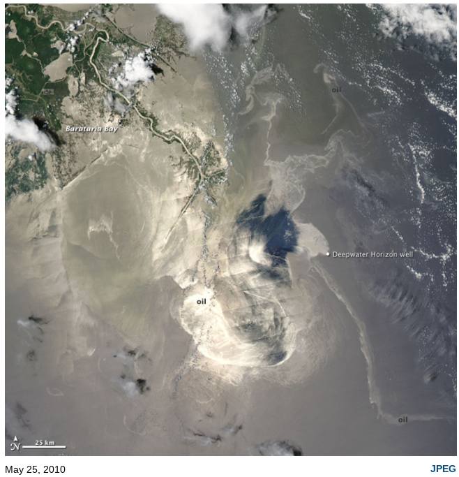

*An image of the sunglint area containing large amounts of surface oil. You can observe the changes in the reflectance of the oil as you move away from the center of the sunglint(right side of the image).* [Credit: NASA Earth Observatory](https://earthobservatory.nasa.gov/images/44076/oil-slick-in-the-gulf-of-mexico)

Because we know the sensor(MODIS) and the date, let us try to recreate this image in GEE.

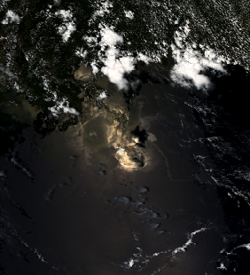

```javascript
// A point representing the general location of deepwater horizon oil rig.
var dw = ee.Geometry.Point([-88.36555556,28.73805556]);

// Pull in MODIS Aqua imagery and visualize the sunglint oil.
var mod2 = ee.ImageCollection("MODIS/006/MYD09GA")
  .filterDate("2010-05-25","2010-05-26");

// Add to map.
Map.addLayer(mod2, {bands: ["sur_refl_b01","sur_refl_b04","sur_refl_b03"],
gamma: 1,
max: 10278.86,
min: 192.14000000000001,
opacity: 1}, "mod2");

// Add Deepwater Horizon location to map.
Map.addLayer(dw,{},"DWH");
```

*A recreation of the MODIS image above created in GEE. You can adjust the gamma to brighten the image slightly.*

While not as clear, the image below shows the plume of smoke visible the day after the initial explosion. The Deepwater Horizon drill rig burned for two days before sinking to the bottom of the ocean.

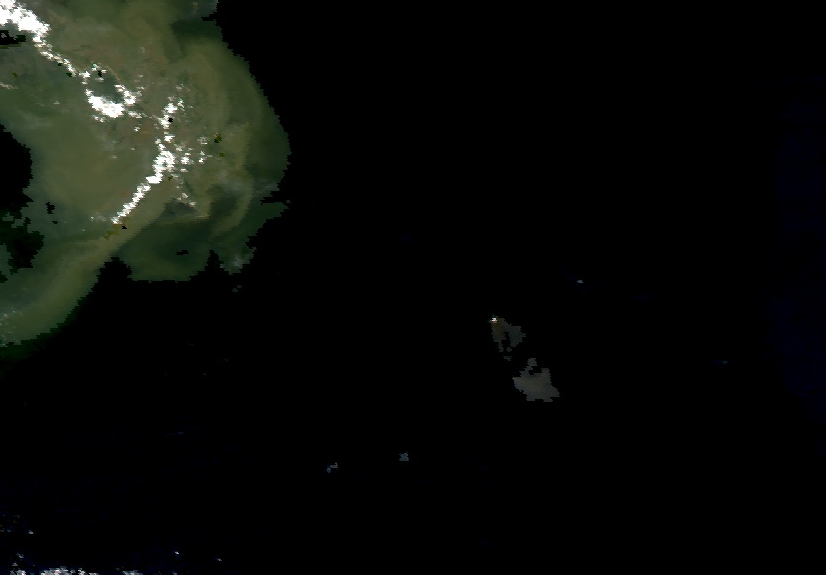

```javascript
// Pull in MODIS aqua imagery and filter for specific date.
var smokePlume = ee.ImageCollection("MODIS/006/MYD09GA")
  .filterDate("2010-04-21","2010-04-22");

// Add to map.
Map.addLayer(smokePlume, {bands: ["sur_refl_b01","sur_refl_b04","sur_refl_b03"],
gamma: 1.32,
max: 3278.86,
min: 192.14000000000001,
opacity: 1}, "smokePlume");
```

*While not the best quality image, the lighter area presence in the ocean to the south east of the sediment rich outlet of the Mississippi River is the smoke from the burning Deepwater Horizon oil rig.*

Obviously, there is a lot of qualitative value in this imagery and to get at that quickly we are going to make a time lapse movie of the MODIS imagery during the period when oil was actively leaking.

# 4 Video of Landscape Change

GEE started as a project to develop a cloud-free mosaic of the globe using Landsat imagery. This product became the base map for Google Earth. Once the cloud-free mosaic was created, the next products produced using the GEE infrastructure were time lapse videos of major landscape change. These videos are very engaging and somewhat frightening depictions of the drastic changes occurring on the surface of our planet. It is worth spending a few minutes looking at some of the premade [examples](https://earthengine.google.com/timelapse/).

To create one of these videos we need to accomplish three things.

1. Define a regions of interest.
2. Pull in images along a date range.
3. Define visualization parameters.

To create the region of interest, we will buffer around the previous location of the Deepwater Horizon drill rig. GEE will use the min max dimension of the buffer area to set the bounding box for the video. Basically, we still end up with a square even though our shape on the map is a circle.

```javascript
// Buffer around the deep water horizon site.
var buffer = dw.buffer({distance:150000} );

Map.addLayer(buffer, {}, 'buffer');
```

We will continue to use Aqua MODIS surface reflectance imagery, so we can use our previous visualization parameters. In this case, we are selecting images over a four month period. There will be approximately 120 images in the video.

```javascript
// Define the visualization parameters.
var vis = {gamma: 1,
max: 10278.86,
min: 192.14000000000001,
opacity: 1};


var collection = ee.ImageCollection("MODIS/006/MYD09GA")
  // Get four months of imagery.
  .filterDate('2010-04-01','2010-7-30')
  // Need to have 3-band imagery for the video.
  .select(['sur_refl_b01', 'sur_refl_b04', 'sur_refl_b03'])
  // Use the map function to apply the same visualizations to all images.
  .map(function(image) {
    return image.visualize(vis);
  });

Map.addLayer({eeObject: collection, name:'Video images'});
```

With these elements in place the last step is to export the video. This works just as any other export function in GEE. This is a video, so there are some unique parameters, which are specific to the video quality.

`Dimensions`: The pixel resolution of the video. 720 by 720 is assumed when providing a single number.

`FramesPerSecond`: defines the number of images displayed per second. We are displaying about 120 images, so at four frames per second our video will be about 30 seconds long. If you want to use this video for more qualitative assessment you could drop it to as low as 1 frame per second.

```javascript
// Export (change dimensions or scale for higher quality).
Export.video.toDrive({
  collection: collection,
  description: 'modisDWH',
  dimensions: 720,
  framesPerSecond: 4,
  region: buffer
});
```

As with any export from GEE you will need to exicute this process by selecting the run button in the task pane after you run the script. Exporting this video will take some time. Depending on your connection speed and the parameters you selected for the video, expect this process to take between 10 and 20 minutes. Creating a video of your area of study can give you an interesting and engaging resource that showcases some of the character of this region. The video will make it clear the Gulf of Mexico is a generally cloudy place but, there will be images when the sunglint oil shines bright. In the next step of this module were going to look into more quantitative methods for comparing the photosynthetic activity of this region over time.

Example of the video can be found [here](https://drive.google.com/open?id=1ZARdaAt-eYtP1sUKIDkAg9qS49OlU-9k).

# 5 Ecological Impact of the Deepwater Horizon Spill

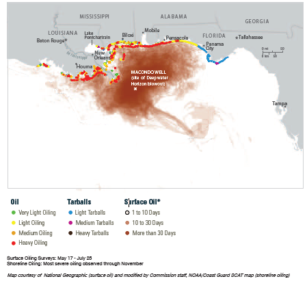

## 5.1 Algal Blooms

While the Deepwater Horizon event is an example of point source pollution. But the Gulf of Mexico, specifically around the Mississippi River delta, has been dealing with non-point source pollution for some time. The Mississippi River drains roughly a third of the land mass in the United States and much of this area is under intensive agricultural development. To grow plants, extra nutrients such as nitrogen and phosphorus are applied to the agricultural fields. While these nutrients are used by plants, it is inevitable that some are washed out in precipitation events and eventually make it to the ocean. The result is that natural occurring algal populations receive extra nutrients and they bloom in tremendous numbers.

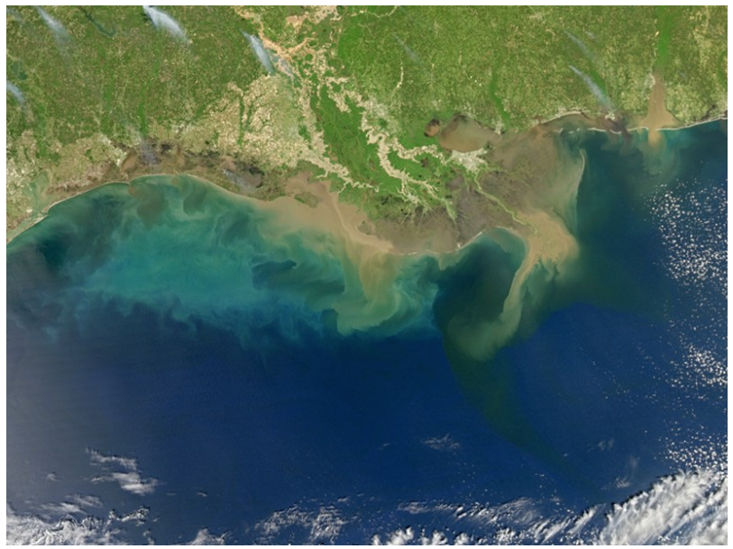

*Spring time floods bring a tremendous about of sediment and dissolved nutrients into the Gulf of Mexico. This can dramatically increase algae populations along the coast. The algal blooms are visible as the light green color in the water along the coast.* [Credit: NASA Earth Observatory](https://earthobservatory.nasa.gov/images/38273/sediment-in-the-gulf-of-mexico)

This true color MODIS image above shows both sediment plumes (tan color) and algal blooms (green color) resulting from the spring high water events that frequent the Mississippi River delta. We are going to attempt to see if there is a measurable difference in the algal bloom extent and intensity during the year where oil was persistent on the ocean surface compared to the years where it was not.

## 5.2 MODIS Chlorophyll-a Product

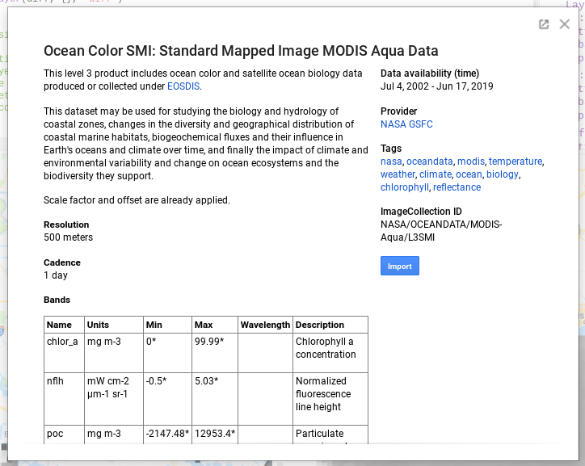

*Description of the MODIS Ocean Color image collection available in GEE.*

The “chlor_a” band is a near-surface concentration of chlorophyll-a and is based on an empirical relationship between the blue and green bands of the MODIS sensor. Chlorophyll-a is the primary molecule responsible for photosynthesis and is what contributes to the green color in plants. By mapping chlorophyll-a concentration, we are working under the assumption that algae are the primary source of this molecule in this region of the ocean.

## 5.3 Differencing Two Years of Imagery

It is worthwhile to generate some simple visualizations of the ecological feature you are interested in as soon as you have the correct imagery to do so. We will do this by generating maps of chlorophyll-a density for both 2009 and 2010. We will also take the difference between these two images to visualize the spatial patterns in chlorophyll-a density between the two years.

We will filter our dataset a to capture the months that the oil well was actively leaking.

```javascript
// Define visualization parameters so the images are both presented in the same way.
var vis2 = {min:-7, max:14};

// Generate the based dataset for our processes.
var mod09 = ee.imageCollection("NASA/OCEANDATA/MODIS-Aqua/L3SMI")
  .filterDate("2009-04-20","2009-07-31")
  .select("chlor_a")
  .median();
Map.addLayer(mod09, vis2, "09");

// Generate the based dataset for our processes.
var mod10 = ee.imageCollection("NASA/OCEANDATA/MODIS-Aqua/L3SMI")
  .filterDate("2010-04-20","2010-07-31")
  .select("chlor_a")
  .median();
Map.addLayer(mod10, vis2, "10");

// Difference the model by subtracting.
var diff = mod10.subtract(mod09);
Map.addLayer(diff, {min:-6, max:6}, "diff");
```

Use the inspector tool to look at the difference in values. Darker areas suggest more algae present in 2009, lighted areas suggest more algae present in 2010.

[figure not shown]

*Difference in algal concentrations between 2009 and 2010. Dark areas represent regions of decreased algal concentrations and light areas are regions of increase algal concentrations between the two years.*

Seeing that very dark area makes it easy to assume that the oil is having an effect on the algal productivity, yet this is a complex system and as a result it is better to look at trends in the data rather than a direct comparison of just two time steps. We will examine two different methods for looking at the trend of algal productivity over time.

# 6 Trend Analysis Across the MODIS Collection

Trend analysis of remote sensing data is a large field of study. It is an important feature in many studies because in complex systems singular events might be impactful in the short term but due to the resilience of the systems, they have little effect on ecosystem function over time. With the MODIS sensor we have data regarding algal concentrations from 2002 to present. We will be preparing these data using two different methods to highlight the variability in averages as well as daily measurements over time. Both methods highlight different trends and provide unique information on the effect of the oil spill on the algal populations.

## 6.1 An Median Value Approach.

In the image comparison approach above we looked at the difference between two images. In this example, we will develop a method that allows us to make a similar comparison across all years of available data. We will automate this process a bit by creating a dictionary of median reduced images from across the time period during which the oil well was leaking. We are using a custom built function to construct our image dictionary. This function requires some adaptation on the user’s part so we have included some descriptive text in the instructions so the user knows what exactly is needed. This is a great practice if you find yourself generating functions that are being used in many different situations by people other than you.

```javascript
var constructMODDict = function(geometry)
  /*
  This function takes in a geometry feature from the GUI and uses it to
  generate a dictionary of median reduce images for the specified date range
  inputs
  geometry = geometry object representing you area of interest
  y_list = set based on sensor type
  imagecollection = unique id for collection type
  filterDate = cat() this is used to refine the month and day of start and end time
  With adaptation this should be flexible across sensors and times
  */
  {
  var startMonth = "-04-20";
  var endMonth = "-07-31";
  // Construct a dictionary for MODIS.
  var y_list = ee.List.sequence(2002, 2018);
  var ystr_list = y_list.map(function(y){return ee.Number(y).format('%1d')});
  var mod = y_list.map(function(y){return ee.ImageCollection('NASA/OCEANDATA/MODIS-Aqua/L3SMI')
                                          .filterDate(ee.String(ee.Number(y).format('%1d')).cat(startMonth),
                                                      ee.String(ee.Number(y).format('%1d')).cat(endMonth))
                                          .select("chlor_a")
                                          .median()
                                          .clip(geometry);
  })
  var mod_dict = ee.Dictionary.fromLists(ystr_list, mod);
  // Return MODIS dictionary.
  return mod_dict;
};
```

Conceptually, this function is pulling in all images over a set date range, selecting a specific band, applying a median reducer, and clipping the image to a geometry feature. We want to do this over multiple years, so we are creating a list of the years we are interested in. That list is converted to `ee.Number` objects, which is use to select and manipulate images for all the years in the list. When an image is created it is stored in a list. Then we convert that list to a dictionary which allows us to intuitively keep track of the image by defining its key to be the year that it represents. We will use this dictionary again in [Module 10](https://ecodata.nrel.colostate.edu/gdpe-gee-remote-sensing-lessons/module10.html).

Running the function above brings the feature into memory. Below, we call the function and provide a geometry feature as the input. It would be good to create a new geometry feature that includes more of the shoreline of Louisiana, Mississippi, and Alabama. Reference the map of coastal areas impacted in Section 5. *Ecological Impact of the Deepwater Horizon Spill* and make sure it includes a good 20 or 30 miles off ocean the coast. Algae are most prevalent in shallow waters but we want to be inclusive of potential habitat. Name this geometry feature ‘geometry2’.

```javascript
// Apply function across the new geometry.
var elements = constructMODDict(geometry2);
print(elements, "Image dictionary");
```

The image dictionary is a convenient feature to store our data because we can use keys that represent the year the image was captured to select images. This makes it easy to sort and understand what image you are working with. That said, dictionaries are not useful for displaying and running analysis on imagery. Because of this, we are going to create an image collection from our dictionary.

```javascript
// Convert the images in the dictionary to an image collection.
var collection2 = ee.ImageCollection.fromImages([
  ee.Image(elements.get('2002')),
  ee.Image(elements.get('2003')),
  ee.Image(elements.get('2004')),
  ee.Image(elements.get('2005')),
  ee.Image(elements.get('2006')),
  ee.Image(elements.get('2007')),
  ee.Image(elements.get('2008')),
  ee.Image(elements.get('2009')),
  ee.Image(elements.get('2010')),
  ee.Image(elements.get('2011')),
  ee.Image(elements.get('2012')),
  ee.Image(elements.get('2013')),
  ee.Image(elements.get('2014')),
  ee.Image(elements.get('2015')),
  ee.Image(elements.get('2016')),
  ee.Image(elements.get('2017')),
  ee.Image(elements.get('2018'))
  ]);

print(collection2)
Map.addLayer(collection2,{},'ic')
```

This is not an efficient method but, it does work. If you have significantly more images in your dictionary you would have to find a more creative method for creating this new image collection. One alternative to explore is the [`map()`](https://developers.google.com/earth-engine/ic_mapping) function in GEE, which works similarly to for loops or the lapply function in R.

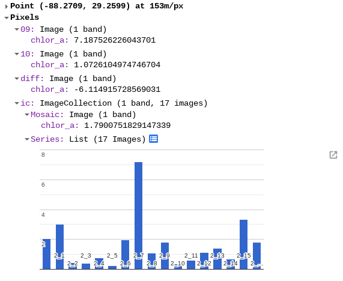

*A histogram showing median chlorophyll-a concentration at a selected location across all available MODIS imagery.*

## 6.2 Trends In Individual Images Over an Area

The example above is an excellent resource for quickly checking the average values across locations of your choosing. However, averages(such as the median of a distribution) can cover up unique elements of the data such as minimun and maximun concentrations. In this example, we will build a similar dataset but will not reduce the images over the year. Therefore, we will have a value for everyday for every year of our choosing.

```javascript
// Define start and end dates.
var start = '2008-01-01';
var end = '2012-12-31';

// Select all images with the months of April to July with a date range
var col = ee.ImageCollection("NASA/OCEANDATA/MODIS-Aqua/L3SMI")
  .filterDate(start, end)
  .filter(ee.Filter.calendarRange(4,7,'month'))
  .filterBounds(geometry2)
  .select("chlor_a");

print(col, "Individual Images By Year");
```

In the code above we are applying a very familiar filtering process with the addition of a new filtering element. The `ee.Filter.calendarRange()` function allows you to filter by temporal elements in the metadata(timestamp, day, month, year) of the image. In our case we are selecting images that were captured between the forth through seventh month of the year. This is an extremly convenient filter!

Create a new geometry feature and place it on the map. You can adjust the size and place of the feature at any time.

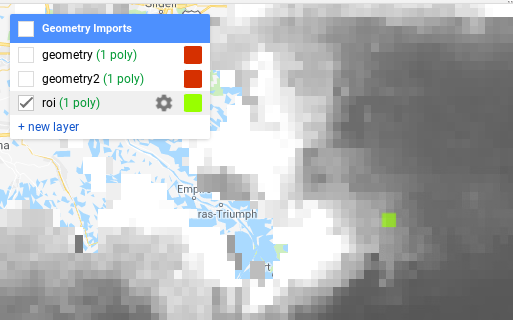

*An example of a small region of interest that can be used to run summary statistics.*

This geometry feature will define where our data will be compiled from. To visualize the data, we are going to use the `ui.Chart()` function. This function requires an imageCollection for input data, a geometry feature to define the region, and a reducer function to compile all elements within the region into a single value.

*Create a new geometry feature of a smaller area, a few square miles, and rename the object “roi”.*

```javascript
// Plot a time series of the chlor_a at a single location or summarize values within an area.
var l8Chart = ui.Chart.image.series({imageCollection: col,
   region: roi,
   reducer: ee.Reducer.median()}
 ).setChartType('ScatterChart');

print(l8Chart);
```

The chart will appear in your console. Use the arrow in the top right corner of the chart to open the chart as a full sized web page. You also have options to save the data or an image of the chart for further work.

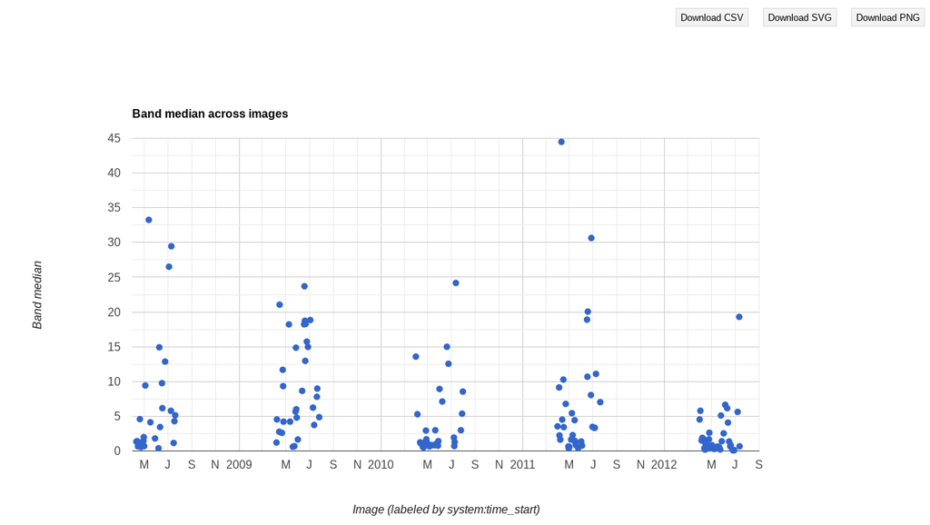

*Daily chlorophyll-a concentrations (when available across) multiple years of imagery over the date range during which oil was being released in 2010.*

It is easy to see how the summarized data and the individual image data are telling slightly different stories. The complexity of the individual image data makes it clear that algal concentration is a very dynamic feature and making scientifically justifiable claims about the change over time would take a good deal of extra work. The important part is that the data is there, it just takes effort.

# 7 Conclusion

In this module, we developed a methodology that allows us to look at time series data of algal concentrations in the Gulf of Mexico to make estimates about the effect of the Deepwater Horizon oil spill on the base trophic level of this ecosystem. The size and complexity of the system indicates that coming to some conclusive results about the actual impact would take a lot of additional work. But what is clear from this process is that GEE offers the computing power and flexibility to conduct time series analysis. Hopefully, you can use these tools and methods to ask your own questions about the long term effect of ecological disturbances over time.

## 7.1 Complete Code

```javascript
// A point representing the general location of deepwater horizon oil rig.
var dw = ee.Geometry.Point([-88.36555556,28.73805556]);

// Pull in MODIS aqua imagery and visualize  so the sunglint oil stands out.
var mod2 = ee.ImageCollection("MODIS/006/MYD09GA")
  .filterDate("2010-05-25","2010-05-26");

// Add to map.
Map.addLayer(mod2, {bands: ["sur_refl_b01","sur_refl_b04","sur_refl_b03"],
gamma: 1,
max: 10278.86,
min: 192.14000000000001,
opacity: 1}, "mod2");

// Add deep water horizon to map.
Map.addLayer(dw,{},"DWH");

// Pull in MODIS aqua imagery and visualize  so the sunglint oil stands out.
var smokePlume = ee.ImageCollection("MODIS/006/MYD09GA")
  .filterDate("2010-04-21","2010-04-22");

// Add to map.
Map.addLayer(smokePlume, {bands: ["sur_refl_b01","sur_refl_b04","sur_refl_b03"],
gamma: 1.32,
max: 3278.86,
min: 192.14000000000001,
opacity: 1}, "smokePlume");

// Buffer around the deep water horizon site.
var buffer = dw.buffer({distance:150000} );

Map.addLayer(buffer, {}, 'buffer');

// Define the visualization parameters.
var vis = {gamma: 1,
max: 10278.86,
min: 192.14000000000001,
opacity: 1};


var collection = ee.ImageCollection("MODIS/006/MYD09GA")
  // Get 4 months of imagery.
  .filterDate('2010-04-01','2010-7-30')
  // Need to have 3-band imagery for the video.
  .select(['sur_refl_b01', 'sur_refl_b04', 'sur_refl_b03'])
  // Use the map function to apply the same visualizations to all images.
  .map(function(image) {
    return image.visualize(vis);
  });

Map.addLayer({eeObject: collection, name:'Video images'});

// Export (change dimensions or scale for higher quality).
Export.video.toDrive({
  collection: collection,
  description: 'modisDWH',
  dimensions: 720,
  framesPerSecond: 4,
  region: buffer
});

// Define visualization parameters so the images are both presented in the same way.
var vis2 = {min:-7, max:14};

// Generate the based dataset for our processes.
var mod09 = ee.featureCollection("NASA/OCEANDATA/MODIS-Aqua/L3SMI")
  .filterDate("2009-04-20","2009-07-31")
  .select("chlor_a")
  .median();
Map.addLayer(mod09, vis2, "09");

// Generate the based dataset for our processes.
var mod10 = ee.featureCollection("NASA/OCEANDATA/MODIS-Aqua/L3SMI")
  .filterDate("2010-04-20","2010-07-31")
  .select("chlor_a")
  .median();
Map.addLayer(mod10, vis2, "10");

// Difference the model by subtracting.
var diff = mod10.subtract(mod09);
Map.addLayer(diff, {min:-6, max:6}, "diff");

var constructMODDict = function(geometry);
  /*
  This function takes in a geometry feature from the GUI and uses it to
  generate a dictionary of median reduce images for the specified date range
  inputs
  geometry = geometry object representing you area of interest
  Features to change
  y_list = set based on sensor type
  imagecollection = unique id for collection type
  filterDate = cat() this is used to refine the month and day of start and end time
  With adaptation this should be flexible across sensors and times
  */
  {
  var startMonth = "-04-20"
  var endMonth = "-07-31"
  // Construct a dictionary for MODIS.
  var y_list = ee.List.sequence(2002, 2018)
  var ystr_list = y_list.map(function(y){return ee.Number(y).format('%1d')})
  var mod = y_list.map(function(y){return ee.ImageCollection('NASA/OCEANDATA/MODIS-Aqua/L3SMI')
                                          .filterDate(ee.String(ee.Number(y).format('%1d')).cat(startMonth),
                                                      ee.String(ee.Number(y).format('%1d')).cat(endMonth))
                                          .select("chlor_a")
                                          .median()
                                          .clip(geometry)
  })
  var mod_dict = ee.Dictionary.fromLists(ystr_list, mod);
  // Return MODIS dictionary.
  return mod_dict
};

// Apply function across the new geometry.
var elements = constructMODDict(geometry2);
print(elements, "Image dictionary");

// Convert the images in the dictionary to a image collection.
var collection2 = ee.ImageCollection.fromImages([
  ee.Image(elements.get('2002')),
  ee.Image(elements.get('2003')),
  ee.Image(elements.get('2004')),
  ee.Image(elements.get('2005')),
  ee.Image(elements.get('2006')),
  ee.Image(elements.get('2007')),
  ee.Image(elements.get('2008')),
  ee.Image(elements.get('2009')),
  ee.Image(elements.get('2010')),
  ee.Image(elements.get('2011')),
  ee.Image(elements.get('2012')),
  ee.Image(elements.get('2013')),
  ee.Image(elements.get('2014')),
  ee.Image(elements.get('2015')),
  ee.Image(elements.get('2016')),
  ee.Image(elements.get('2017')),
  ee.Image(elements.get('2018'))
]);

print(collection2)
Map.addLayer(collection2,{},'ic')

// Define start and end dates.
var start = '2008-01-01';
var end = '2012-12-31';

// Select all images with the months of April to July with a date range
var col = ee.ImageCollection("NASA/OCEANDATA/MODIS-Aqua/L3SMI")
  .filterDate(start, end)
  .filter(ee.Filter.calendarRange(4,7,'month'))
  .filterBounds(geometry2)
  .select("chlor_a");

print(col, "Individual Images By Year");

// Plot a time series of the chlor_a at a single location or summaries values within an area.
var l8Chart = ui.Chart.image.series({imageCollection: col,
   region: roi,
   reducer: ee.Reducer.median()}
 ).setChartType('ScatterChart');

print(l8Chart);
```